# **1. 인덱싱(Indexing)**

- 사전적으로는 무엇인가 "가르킨다"를 의미합니다.
- 즉, 인덱싱(Indexing)은 특정한 값을 뽑아내는 역할을 합니다.
- 예시) x = Rome is not built in a day!

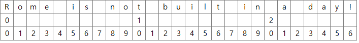

```python
x = "Rome is not built in a day!"
```

```python
x[0]
```

```
'R'
```

```python
x[-1]
```

```
'!'
```

```python
x[-2]
```

```
'y'
```

```python
x[-6]
```

```
'a'
```

# **2. 슬라이싱(Slicing)**

- 사전적으로는 무엇인가 "잘라낸다"를 의미합니다.
- 아래 예시에서 원하는 단어를 뽑아내고자 할때 슬라이싱을 사용할 수 있습니다.
- 예시) x = Rome is not built in a day!
- Sliicing의 형태 : x[시작번호 : 끝번호]

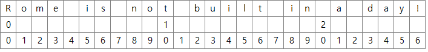

```python
x[0:4]
```

```
'Rome'
```

```python
# 끝 번호를 삭제 한다면 ..
x[12:]
```

```
'built in a day!'
```

```python
# 시작번호를 삭제 한다면 ..
x[:7]
```

```
'Rome is'
```

```python
# 시작번호, 끝번호를 삭제 한다면 ..
x[:]
```

```
'Rome is not built in a day!'
```

```python
# 슬라이싱도 인덱싱 처럼 (-)기호를 사용할 수 있다.
x[12:-7]
```

```
'built in'
```

# **3. Pandas 자료형**

- 자료형 : 프로그래밍을 할 때 쓰이는 숫자, 문자열 등 자료 형태로 사용하는 모든 것
- 자료형은 데이터를 이해하는데 가장 기본이자 중요한 요소입니다.

### **3-1. 자료형의 종류**

- string (문자열) : 문자, 단어 등으로 구성된 문자들의 집합 ex) "Hello World" , "123" , "a"
- integer : 숫자형 데이터 중 정수형 ex) 123, -234
- float : 소수점이 포함된 숫자 ex) 1.2, -2.34

### **3-2. 리스트 자료형**

- 순서대로 정리 된 항목들을 담는 구조(특정 데이터를 반복적으로 처리하는데 특화 되어 있음
- 리스트는 [ ]로 감싸고 각 요소는 ,로 구분한다.

#### **1) 리스트의 생성**

- 리스트명 = [데이터, 데이터, 데이터]
- 리스트명 = list(range(시작 값, 종료 값, 증가 or 감소)

```python
a=[1,2,3]
a

a_list = [1, 2, 3]
a_list
```

```
[1, 2, 3]
```

```python
b=list(range(1,10,2))
b

a_range = list(range(1, 20, 3))
a_range
```

```
[1, 4, 7, 10, 13, 16, 19]
```

#### **2) 리스트 관련 함수**

- 리스트.append(요소) : 리스트의 끝에 요소 추가
- 리스트.insert(인덱스, 요소) : 리스트의 특정 인덱스에 요소 추가
- 리스트1.extend(리스트2) : 리스트1에 리스트2를 연결해 확장
- 리스트1 + 리스트2 : 리스트1과 리스트2를 서로 병합
- 리스트.remove(요소) : 리스트의 특정 값의 요소를 삭제
- 리스트.count('요소') : 리스트 중 특정 값을 가진 요소의 개수를 카운트
- 리스트.sort() : 리스트 내 요소를 오름차순으로 정렬
- 리스트.pop(인덱스) : 리스트 중 특정 인덱스의 요소를 삭제

```python
a = ['red', 'green', 'blue']
a.append('yellow')
a
```

```
['red', 'green', 'blue', 'yellow']
```

```python
a.insert(1, 'black')
a
```

```
['red', 'black', 'green', 'blue', 'yellow']
```

```python
b = ['purple', 'white']
a.extend(b)
a
```

```
['red', 'black', 'green', 'blue', 'yellow', 'purple', 'white']
```

```python
c = a+b
print(c)
```

```
['red', 'black', 'green', 'blue', 'yellow', 'purple', 'white', 'purple', 'white']
```

```python
d = [10, 20, 30, 40, 50, 60, 70, 80, 90, 100]
d.remove(90)
d

#remove(value)
```

```
[10, 20, 30, 40, 50, 60, 70, 80, 100]
```

```python
list1 = ['a', 'bb', 'c', 'd','aaa', 'c', 'ddd', 'aaa',  'b', 'cc', 'd', 'aaa', ]
list1.count('aaa')
```

```
3
```

```python
list2 = [1, -7, 5, 8, 3, 9, 11, 13]
list2.sort()
list2
```

```
[-7, 1, 3, 5, 8, 9, 11, 13]
```

```python
list2.sort(reverse=True)
list2
```

```
[13, 11, 9, 8, 5, 3, 1, -7]
```

```python
d = [10, 20, 30, 40, 50, 60, 70, 80, 90, 100]
d.pop(0)
d
```

```
[20, 30, 40, 50, 60, 70, 80, 90, 100]
```

### **3-3. 튜플(Tuple)**

- 리스트와 거의 유사하고 사용법도 동일함
- 라스트는 [ ] 으로 둘러싸지만 튜플은 ( )으로 둘러싼다.
- 튜플에서는 리스트와 달리 요소들의 수정과 추가 불가

#### **1) 튜플 생성**

- 튜플명 = ( 데이터, 데이터, 데이터, ... )
- 튜플명 = 데이터, 데이터, 데이터, ...

```python
t1 = ('banana', ' apple', 'kiwi')
t1
```

```
('banana', ' apple', 'kiwi')
```

```python
t2 = 'banana', 'apple', 'kiwi'
t2
```

```
('banana', 'apple', 'kiwi')
```

```python
# 튜플은 변환이 불가능 하기 때문에 에러 발생
t2[0] = 'watermelon'
#수정이나 삭제를 할수 없음
```

```
---------------------------------------------------------------------------
TypeError                                 Traceback (most recent call last)
<ipython-input-24-4eb8eff8bcf2> in <module>
      1 # 튜플은 변환이 불가능 하기 때문에 에러 발생
----> 2 t2[0] = 'watermelon'
      3 #수정이나 삭제를 할수 없음

TypeError: 'tuple' object does not support item assignment
```

#### **2) 튜플의 장점**

- 튜플은 반복 처리 시 리스트에 비해 근소하게나마 빠르다. (연산량이 많은 경우 약간의 성능 향상)
- 튜플은 요소를 변경할 수 없는 특성으로 인해 딕셔너리의 키로 사용할 수 있다. (리스트는 사용 불가)
- 튜플은 요소를 변경할 수 없기 때문에 보안을 요하는 데이터를 보호하는 장점을 가지게 된다.

### **3-4. 딕셔너리(Dictionary)**

- 사전이 단어와 뜻으로 구성되듯, 키(key)와 값(Value)의 쌍으로 갖는 자료형

#### **1) 딕셔너리 생성**

- 딕셔너리명 = {key1:value1, key2:value2, key3:value3, ...}
- 딕셔너리 key 값으로 튜플은 사용 가능 하지만 리스트는 사용불가

```python
members = {'name':'안지영', 'age':30, 'email':'jiyoung@korea.com'}
members
```

```
{'name': '안지영', 'age': 30, 'email': 'jiyoung@korea.com'}
```

#### **2) 딕셔너리 관련 함수**

- keys : 딕셔너리에 key만 모아서 반환
- vlaues : 딕셔너리에 value만 모아서 반환
- items : key, value쌍을 튜플로 묶은 값을 반환
- clear : key,vallue 모두 지우기
- get : key로 value 얻기
- in : 해당 key가 딕셔너리 안에 있는지 조사하고자 하는 경우 사용

```python
members.keys()
```

[output not shown]

```python
members.values()
```

[output not shown]

```python
members.items()
```

[output not shown]

```python
members.get('name')
```

[output not shown]

```python
'name' in members
```

[output not shown]

```python
'birth' in members
```

[output not shown]

```python
members.clear()
members
```

[output not shown]

### **3-5. List, Tuple, Dictionary차이**

[output not shown]